# Changes in R

We present selected changes in the development version of R, which is referred to as R-devel and is to become R 4.5. We also provide some statistics on bug tracking activities in 2024, which covers 4 months before the release of R 4.4 and 8 months of work on R-devel.

## 1 Selected changes in R-devel

R 4.5.0 is due to be released around April 2025. The following gives a selection of changes in R-devel, which are likely to appear in the new release.

For a more complete list of changes, run `news(is.na(Version))` in R-devel or inspect the nightly rendered version of the `NEWS.Rd` source file at https://CRAN.R-project.org/doc/manuals/r-devel/NEWS.html or its RSS feed at https://developer.R-project.org/RSSfeeds.html. The bundled *R News* give concise descriptions of a large number of changes, including many smaller ones.

### 1.1 Selected user-visible changes

- R packages for installation are now downloaded in parallel, which improves the download speed, on some systems by a large factor.

  Existing support for simultaneous download in `download.files()` has been improved and functions `install.packages()` and `download.packages()` now use it with the default download method (`libcurl`). Downloading a single file requires a number of handshakes between the client and the server, which may be expensive especially on connections with large latencies. With simultaneous download, existing connections to the same server may be re-used and handshakes be made in parallel with each other and with other transfers. The actual speedup depends on network characteristics, but significant speedups have been observed both with some very good as well as with some rather poor network connections.

  The speedups are bigger when HTTP version 2 is used, which depends on the server (many CRAN mirrors support it) and when the curl library used on the client supports it (on Unix and macOS it typically does, on Windows the upcoming Rtools45 will support it).

  More details about this work can be found in a blog post at https://blog.r-project.org/2024/12/02/faster-downloads. The previous implementation of simultaneous download has been improved to be more careful about available resources, particularly available file handles.

  The implementation of R internet timeout has been improved to allow parallel downloads of many files, though there is a semantic gap between an absolute-time timeout in R and simultaneous download, where transfers may be delayed by ongoing transfers and various connection assets may be re-used between transfers.

  The status reporting for simultaneous transfers in `download.file()` has been improved so that the caller can easily find out which individual transfers have succeeded. The simultaneous download can be used directly also for other files, not only R packages.
- One can now enter and edit arbitrarily long input lines in the R console on Linux and macOS (when the Readline library is used, which is normally the case) and in Rterm on Windows. Arbitrarily long input lines can also be used in Rgui on Windows, but only the last segment can be edited. In previous versions of R, there was a hard-coded limit of about 4K bytes, which worked fine for input entered manually, but some users ran into problems when pasting generated code. On some systems the input was truncated, with Rgui on Windows it could also be corrupted.

  More details about this work can be found in a blog post at https://blog.r-project.org/2024/08/30/long-input-lines. The R parser itself is always invoked on a fixed-length prefix of the input. When the prefix turns out too short to make any progress parsing, the parser is re-started with a longer prefix and the length is potentially unlimited. This iterative mechanism is exposed in Rgui on Windows, when the user can enter additional segments of the line, but then cannot edit the previous segment anymore. Still, several bugs leading to input corruption were found during this work and fixed.

  Readline, used on Linux and macOS in R, allows to edit lines of arbitrary length, so an intermediate layer has been implemented which provides the input to the parser using that iterative mechanism. Rterm on Windows uses a rewrite of getline library, which has been extended to support editing lines of arbitrary length, and again an intermediate layer has been implemented to provide that to the parser.
- Support for the SHA-256 hashing algorithm has been added to R’s tools package via function `sha256sum()`. It allows hashing files on disk and `raw` vectors of bytes in memory. The underlying implementation used is public domain code written by Ulrich Drepper. SHA-256 from the SHA-2 family of hash functions is considered more secure than MD5 (`md5sum()`) and hence is more appropriate whenever the aim is to detect not only accidental data corruption, but also malicious modification. SHA-256 is generally slower to compute than MD5 and the checksum is twice as long (MD5 is 128-bit). `md5sum()` has been extended to also support computation of a hash of `raw` vector of bytes in memory, so that it has the same interface as `sha256sum()`.
- R now supports `zstd` compression. Function `zstdfile()` has been added which allows to create R connections to read from and write to zstd-compressed files. One can use zstd compression with serialization and there is also some support for zstd compression in the `tar()` and `untar()` functions. The zstd compression support is currently optional in R builds: it is only included when the zstd library is available at build time on Unix. On Windows, the zstd library is part of Rtools so zstd support is always available.

  With the default tuning options used currently in R, `zstd` offers typically slightly worse compression than `xz`, but is faster. The tradeoffs, however, become different with other tuning options.
- There is a new wrapper function `grepv(...)`, short hand for `grep(..., value = TRUE)`, to return the matching elements themselves rather than their indices.
- A PDF document may include metadata in the so-called *document information dictionary*. For instance, PDF documents produced by R’s `pdf()` device always set `"R"` as `Creator` and by default use `"R Graphics Output"` as `Title`. An additional argument `author` has now been added to set the `Author` entry (omitted by default), possibly via `pdf.options()` in an R profile or init script. Furthermore, the new logical arguments `timestamp` (setting `CreationDate` and `ModDate`) and `producer` (`"R <major>.<minor>"`) can be set to `FALSE` to disable the corresponding metadata fields. Disabling automatic timestamps simplifies tracking uncompressed PDF output in version control systems.
- `R CMD check` gains an option `--run-demo` to check the R scripts in the `demo` directory similar to those in `tests`. This means demos are run, potentially compared to reference output in corresponding `.Rout.save` files, and it is checked that required R packages are declared in the `DESCRIPTION` file. Whereas package tests are not installed by default, demos are and are thus exposed to users, so package maintainers should ensure they work. The new check option provides an alternative to including `demo()` calls in examples or test scripts. Demos may be interactive (e.g., some await a browser response, require authentication, or contain instructions for special data or software setups) and are sometimes used for computationally intensive examples (e.g., replication scripts from associated publications), so `R CMD check` does not run demo scripts by default (similar to `\donttest` examples, which are only checked with option `--run-donttest`). Package maintainers could add an explicit condition such as `if (!interactive()) quit()` to demo scripts that require interaction, so (occasional) checks with `--run-demo` can be used to cover the others.

  At the time of writing, 603 (3%) of 22133 packages on CRAN contained a demo directory. Of these packages, 117 used undeclared packages in demo scripts. Experiments showed that dozens indeed required an interactive user or a special setup, and others did not complete within 90 minutes (the chosen timeout on the test system). Of the remaining 504 packages, 346 (69%) produced noteworthy errors: a considerable amount of 275 packages failed a demo with “could not find function” or “object not found” errors, often simply because the script forgot to attach the own package, and sometimes because functionality has been removed in the meantime. Remaining issues include coding errors that are catched in recent versions of R (e.g., length > 1 conditions), dead URLs, or breakage that is likely caused by changes in dependencies.

### 1.2 Selected low-level changes

A number of changes in R-devel — perhaps more than usual — are low-level and invisible to R users, but important for the reliability and maintainability of R and R packages now and in the future. Some changes of this kind are listed here.

- Progress has been made on improving the C API for R packages and embedding applications. The interface has evolved organically over the years, sometimes exposing more than necessary or helpful. With some functions it is too easy to make errors leading to segfaults or incorrect results. Some functions expose too much internal structure or behavior, which needs to be changed occasionally to be able to maintain and improve R itself.

  The interface is defined in the ‘Writing R Extensions’ manual, see `RShowDoc("R-exts")` in your version of R or online at https://CRAN.R-project.org/manuals.html: what is mentioned there and is available in installed header files (in directory `R.home("include")`) is in the API. Most internal functions not in the API are “hidden” in the dynamic libraries, which prevents their accidental use. In R-devel they are now hidden also on macOS, previously only on Windows and Linux.

  Some non-API functions currently have to remain unhidden, because they are needed by base R packages that are part of the R distribution and are maintained with R. The cleanup involved hiding some functions that were unnecessarily exposed, replacing some functions with safer alternatives, and adding some to the API by documenting them. This required cooperation of package authors and was tested and tuned on CRAN and Bioconductor packages.

  The ‘Writing R Extensions’ manual has been improved so that functions/symbols in the API are explicitly flagged to be in the (regular) API, Fortran API (for Fortran code), experimental API (subject to change, so users must be prepared to adapt much more than with other categories), or embedding API (only for applications embedding R, including front-ends). There is now internal functionality in R that can query if a given symbol is in the API, which allows stricter checking.
- R includes a number of workarounds for bugs in the iconv library shipped with recent versions of macOS. The library is used for encoding conversions, e.g., when converting between Latin-1 and UTF-8. Despite most R installations today use UTF-8 as the native encoding, such conversions are still happening, e.g., for plot labels and when importing historical data from legacy file formats.

  The iconv implementation that appeared in macOS 14.0 changed the behavior with characters not representable in the target encoding, but also caused crashes with legitimate use and caused incorrect conversions (garbage in output), which has been detected by R developers and users. The bugs lead to incorrect behavior with conversion state reset, with incremental conversion of an input stream, and with treating byte-order marks. The details can be found in a blog post at https://blog.r-project.org/2024/12/11/problems-with-iconv-on-macos.

  The current CRAN builds of R for macOS use a static build of the iconv library that existed in earlier versions of macOS (still truly GNU libiconv 1.11), so are not yet exposed to these problems. However, users building R from source on macOS would run into them if not applying workarounds. R 4.4 already included some of these workarounds, but R-devel includes more and the previous ones have been improved. Also, R-devel fixes a problem of interaction between one of the older workarounds and an iconv bug causing a problem even in the CRAN builds.

  As iconv would usually be linked dynamically when building R from source, the workarounds are based on runtime tests that are executed on first use of encoding conversion functions. Hopefully these bugs will eventually be fixed upstream in macOS, so that these workarounds can be removed. They represent a surprisingly large amount of code.
- The detection of invalid memory accesses caused by attempts to access elements of empty vectors has been enabled by default and improved to be more robust to different inlining decisions by the compiler. Such an access now causes an immediate crash of R and can be easily located using a debugger. This is achieved via “poisoning”: a data pointer to an empty R vector is intentionally returned invalid.

  Invalid memory accesses can otherwise lead to crashes later in the computation or to incorrect results. As a result of this change, a large number of memory access bugs have been found in CRAN packages and reported to CRAN maintainers. If packages from other repositories, where regular checking against R-devel is not in place, start crashing with R 4.5, this is one of the possible causes.

  The amount of related changes in R-devel is small, but the effort debugging packages and providing fixes or advice to package maintainers has been significant.
- R-devel on Windows has been updated so that it can be built also with some alternative Msys2 toolchains, not only with Rtools. This required changes in the make files and is based on `pkg-config`, which is used for figuring out library dependencies and C preprocessor options. It simplifies testing of the Windows-specific code in R with newer compilers (newer than currently in Rtools) and it allows using sanitizers on this code. Also, newer compilers with better diagnostics may find problems relevant also for the current compilers in Rtools. R-devel has been tested on Windows with some of the Msys2 toolchains and sanitizers. In previous years, some alternative toolchains have also been tested, but it required ad-hoc manual modification of the make files in the R sources.

  This support can also be used for testing package code with alternative toolchains, which however requires some Windows-specific knowledge. It is essential that all code in use is built by the same toolchain, so for these experiments, one needs to start with an empty library. Also, Msys2 uses dynamic linking, so one can only run (test) the result with the corresponding Msys2 toolchain environment. More details are available in a blog at https://blog.r-project.org/2025/01/28/alternative-toolchains-on-windows.
- C23 is a new C standard that brings several new features to the language, including `bool`, `true` and `false` keywords. It is the default standard used by GCC 15, which is expected to be released as stable around the release of R 4.5 . R-devel, as well as the upcoming third patch release of R 4.4, has been made installable with the current pre-release version of GCC 15 and also with older compilers when the C23 standard is selected explicitly.

  R packages affected by this change may either choose to explicitly require some older C standard (possibly C17), or better be updated to work also with C23. R-devel has been switched to use C23 always when the compiler supports it, even when it is not the default standard of the compiler. This change has been tested on CRAN and Bioconductor packages and fixes were provided to the maintainers.

  In addition to the general need of updating code to newer standards so that it can be maintained in the future (say, when other components, e.g., libraries, would use newer standards), some of the C23 features may be useful in R, such as the `bool` type. See ‘Writing R Extensions’, Section 1.2.5 ([online version](https://CRAN.R-project.org/doc/manuals/r-devel/R-exts.html#C-standards)), for more details on the use of C standards with R.
- Further progress has been made on getting rid of symbol remapping, i.e., automated renaming of C symbols like `allocVector()` to `Rf_allocVector()` done by R headers. The remapping causes problems when it accidentally modifies code included via C preprocessor headers. The risks can be minimized by including headers in a certain order, but it is an additional constraint package authors need to think about, and in practice, the conflicts are a common cause of package compilation errors arising after updates of the toolchain, OS, or a library.

  The remapping in R-devel has been disabled for C++ code in packages, because most of the conflicts happened to be found with C++ code. The remapping still remains available and is done by default for C code, but it is recommended not to use the remapping in new C code. The ‘Writing R Extensions’ manual has been updated to use full names of the functions including the prefixes; see Section 6 (“The R API”, [online version](https://CRAN.R-project.org/doc/manuals/r-devel/R-exts.html#The-R-API)), for more details on the re-mapping situation in R-devel.

  Similarly, “strict R headers” are now the default, which means that legacy definitions of `Calloc`, `Realloc`, `Free` and `PI` have been removed. One can still use these allocation functions with the `R_` prefix, and `M_PI` is a standard replacement for `PI`.

  Like with other similar tasks, this required only relatively small changes in R itself, but most of the effort has been spent on testing with CRAN and Bioconductor packages and helping the package maintainers with the necessary updates.

## 2 Bug statistics for 2024

Summaries of bug-related activities over the past year were derived from the database underlying [R’s Bugzilla system](https://bugs.R-project.org/). Overall, 183 new bugs or feature requests (15%) were submitted in 2024, very much like in the previous two years. The top 5 selected components for these reports were “Documentation”, “Low-level”, “Misc”, “Language”, and “Graphics”, where the first and last increased their rank compared to 2023.

The numbers of comments and different contributors in the bug tracking system may be influenced by ‘R Dev Days’ organized by the [R Contribution Working Group](https://contributor.R-project.org/): the bugs are pre-discussed at those events mostly outside the core system, which later receives summarized comments. An ‘R Dev Day’ organized just after UseR 2024 had 8 R Core Team members present, so some “comments” were exchanged in person.

The monthly numbers shown in Figure 1 suggest that more issues were closed in April/May, July/August and November. April/May was around the release of R 4.4, but also one of the ‘R Dev Days’ took place. July/August covers the UseR! 2024 conference with an attached R Core Team meeting and ‘R Dev Day’.

As every year, not all bug reports go through R Bugzilla. Some are picked up from the R-devel, R-pkg-devel or R-help mailing lists. Some come via private communication by e-mail or in person. A number of bugs are always discovered by the R Core Team when testing changes in R or packages; these bugs are usually not reported by any channel, but are fixed directly.

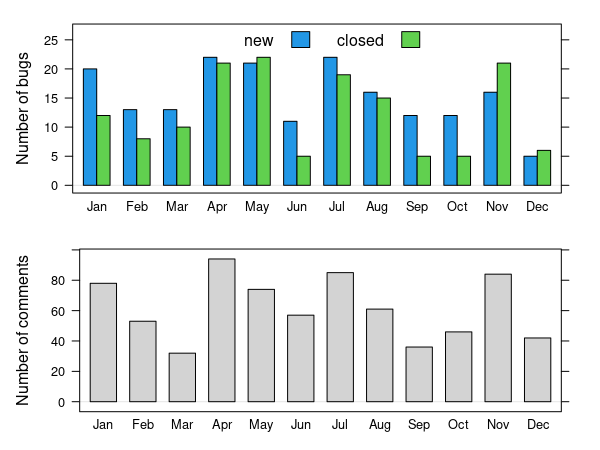

Figure 1: Bug tracking activity by month in 2024.